# BREADTH FIRST SEARCH - WORK DESCRIPTION

**WORK DESCRIPTION OF BFS - BREADTH FIRST SEARCH**

**BFS - BREADTH FIRST SEARCH**

Breadth First Search (BFS) is an algorithm for traversing or searching a graph data structure or tree. It starts at the root node and explores the neighbor nodes first, before moving to the next level neighbors. BFS visits all the vertices of a graph or all the nodes of a tree at a certain depth before going deeper. It is useful for finding the shortest path between nodes in a graph and for solving problems that require searching all neighbors before visiting deeper levels. The algorithm uses a queue data structure to store the nodes that need to be visited.

**ALGORITHM**

1. Initialize a queue with the start node and mark it as visited.  
2. Dequeue the next node from the queue and examine all its unvisited neighbors.  
3. Enqueue the unvisited neighbors and mark them as 'have visited'.  
4. Repeat steps 2 and 3 until either the end node is found or there are no more nodes in the queue.  
5. The end node is found when all its neighbors have been visited, and it is added to the queue.

**CASE 1:**  
start - S  
end- F  
BFS starts with the root node 'S' and moves to the next level neighbour A and explores that level completely i.e B and C as well. It then goes to the next level i.e D, H, L. This cycle is continued until the goal node F is reached.

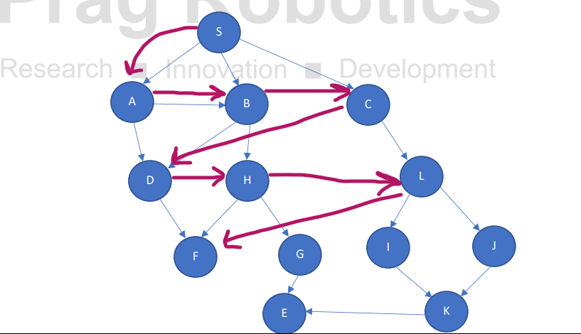

**CASE 2:**  
start - S  
end- E  
BFS starts with the root node 'S' and moves to the next level neighbour A and explores that level completely i.e B and C as well. It then goes to the next level i.e D, H, L. This cycle is continued until the goal node E is reached.

[figure not shown]